# Calling

## Calling Python (and vice versa)

### Calling Python from Julia

Julia provides several API interfaces to Python in different packages:

- PyCall -- low-level interface to Python
- PyPlot -- plotting library `Matplotlib`
- Pandas -- front end to `Pandas` library
- Sympy -- symbolic mathematics library `sympy`
- [ ... YT -- astrophysical package `yt` ... ]

```python
using PyCall

@pyimport math
@pyimport numpy as np
```

```python
math.sin(math.pi) - sin(pi)
```

```
0.0
```

```python
n = pyeval("2^50")
# typeof(n)
```

```
48
```

Interestingly, Julia arrays are wrapped as NumPy array and *shared*, not *copied*.

```python
A = rand(4, 4)
```

```
4x4 Array{Float64,2}:
 0.581857   0.507183  0.230739   0.309339
 0.541774   0.838642  0.828332   0.550917
 0.0760299  0.714324  0.0540574  0.355525
 0.60623    0.299238  0.432295   0.963589
```

```python
Apy = PyObject(A)
```

```
PyObject array([[ 0.58185661,  0.50718263,  0.23073862,  0.30933888],
       [ 0.54177354,  0.83864155,  0.82833172,  0.55091736],
       [ 0.07602986,  0.71432411,  0.05405742,  0.3555251 ],
       [ 0.6062302 ,  0.29923772,  0.43229519,  0.96358937]])
```

```python
# det(Apy)    # not possible, no method det(::PyObject)
np.det(A)     # or: det(convert(Float64, Apy))
```

```
-0.1638918638620552
```

```python
@pyimport scipy.linalg as la    # `@pyimport scipy.linalg` not possible (why?)
Ainv = la.inv(A)
```

```
4x4 Array{Float64,2}:
  2.47741   -0.581389  -1.04385   -0.0777786
  0.383502   0.160237   1.21766   -0.663995
 -1.27247    1.73184   -1.0481    -0.19495
 -1.10686   -0.460945   0.748797   1.38038
```

```python
A[1, 1] = 0.0;
Apy
```

```
PyObject array([[ 0.        ,  0.50718263,  0.23073862,  0.30933888],
       [ 0.54177354,  0.83864155,  0.82833172,  0.55091736],
       [ 0.07602986,  0.71432411,  0.05405742,  0.3555251 ],
       [ 0.6062302 ,  0.29923772,  0.43229519,  0.96358937]])
```

**Example**: Root finding for a difficult and well-known test function

```python
fn(x) = log(x) + x*x/(2.0*exp(1.0)) - 2.0*x/sqrt(exp(1.0)) + 1.0
```

```
fn (generic function with 1 method)
```

This test function is so flat between 1.0 and 3.4 that every root finder except perhaps an arbitrary precision one will not be able to locate this root exactly.  
The true root is obviously `sqrt(e) = 1.6487212707001282`.

```python
# Pkg.add("Roots")
using Roots
```

```python
fzero(fn, 1.0, 3.4)
```

```
1.6487190246582024
```

```python
@pyimport scipy.optimize as spo  # 1-dim: brentq, brenth, ridder, bisect, newton
spo.brentq(fn, 1.0, 3.4)
```

```
1.6487065682417044
```

**Example**: Interpolation and integration

```python
using HDF5
```

HDF5

```python
# h5write("xydata.h5", "xy", [x y])
xy = h5read("xydata.h5", "xy");
x = xy[1:101, 1]; y = xy[1:101, 2];
```

Imagine there is no good enough spline interpolation available in Julia. We utilize the 'interpolate' module in SciPy and do the integration in Julia.

```python
@pyimport scipy.interpolate as si

f2 = si.interp1d(x, y, kind="cubic")

# f2(xx) ? f2 not recognized as 'callable'
# pycall(f2, Float64, pi)
```

```
PyObject <scipy.interpolate.interpolate.interp1d object at 0x7f2748073510>
```

```python
xx = linspace(0, 2*pi, 1000);
yy = pycall(f2, PyAny, xx);
```

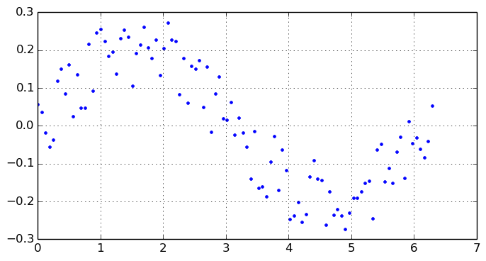

```python
using PyPlot
figure(figsize = (8.0, 4.0))
# plot(xx, yy, "r")
plot(x, y, "b.")
grid()
```

```python
@pyimport scipy.integrate as spq
```

```python
spq.quad(f2, 0.0, pi)
```

```
(0.425203989888956,9.573535663910472e-6)
```

Instead, we transform this interpolated Python function back to Julia and integrate it here using a Gauss-Kronrod quadrature.

```python
f22(x) = pycall(f2, PyAny, x)

quadgk(f22, 0, pi)
```

```
(0-dimensional Array{Float64,0}:
0.425204,6.025219920562742e-9)
```

**Example**: Gauss' Hypergeometric Function

Julia does not have an implementation of the Hypergeometric function 2F1, but Python has.

```python
@pyimport scipy.special as special

println(special.hyp2f1(1/3, 2/3, 5/6, 27/32))  # 8/5
println(special.hyp2f1(1/4, 1/2, 3/4, 80/81))  # 9/5
```

```
1.599999999999999
1.7999999999999983
```

These are two of the very few points where the hypergeometric function takes on rational values.  
Unfortunately, the Python hypergeometric function is spuriously wrong (not inaccurate, but totally wrong) in the complex plane!

#### SymPy

```python
using SymPy
```

```python
x, y, z = Sym(:x, :y, :z)  # or Sym("x y z")
```

```
(x,y,z)
```

```python
limit(sin(x)/x, x, 0.0)
```

$$1$$

```python
z = diff(sin(x)/x, x)
```

$$\frac{1}{x} \cos{\left (x \right )} - \frac{1}{x^{2}} \sin{\left (x \right )}$$

```python
z = integrate(sin(x)/x, x, 1, Inf)
```

$$- \operatorname{Si}{\left (1 \right )} + 1.5707963267949$$

```python
float(z)
```

```
0.6247132564277136
```

### Excursion: Calling C from Julia

Julia has a built-in feature to call functions in external shared libraries (C API). The syntax is  
`ccall((function symbol, library name) return type, (argument types), arguments...)`

```python
c_sin(x) = ccall((:sin,"libm"), Cdouble, (Cdouble,), x)
```

```
c_sin (generic function with 1 method)
```

```python
c_sin(pi/4)
```

```
0.7071067811865475
```

The problem is that this approach will *not* make functions, defined in Julia, available to the C code.  
See the "Rcpp" discussion in R.

### Calling Julia from Python

The `pyjulia` Python module is developing an interface to Julia that works with Python 2 & 3. (`pyjulia` is still in an experimental phase).

```
import julia
j = julia.Julia()

j.eval("2^10")                  #=> 1024
j.eval("2^100")                 #=> 0
j.eval("big(2)^100")            #=> 1267650600228229401496703205376L

j.sqrt(2.0)                     #=> 1.4142135623730951
j.help("sqrt")
  # Base.sqrt(x)

  #  Return \sqrt{x}. Throws "DomainError" for negative "Real"
  #  arguments. Use complex negative arguments instead. The prefix
  #  operator "√" is equivalent to "sqrt".

from julia import randn as r
r(100)

# works with julia and user-defined packages
import numpy as np
x = np.array([0.0, 1.0])

from julia import NumericalMath
NumericalMath.trapz(x, x)
# 0.5
```